# Generating and fitting data from marginalized, proportional odds and partial proportional odds models

Jonathan S. Schildcrout

2022-02-10

```r
#library(Rcpp)
library(knitr)
library(kableExtra)
library(OMTM1)
library(viridis)
col.vir=viridis(9)
lo = function(x) log(mean(x)/(1-mean(x)))
plot.states.lo = function(data, the.subgroup, Yvar, timevar, the.title){

    data$State = as.numeric(data[,Yvar])
    dat1       = subset(data, subset=eval(parse(text=paste(the.subgroup))))
    dat1$t     = dat1[,timevar]
    lid        = length(unique(dat1$id))

    l1 = tapply(dat1$State<=1, dat1$t, lo)
    l2 = tapply(dat1$State<=2, dat1$t, lo)
    l3 = tapply(dat1$State<=3, dat1$t, lo)
    times = sort(unique(dat1$t))
    plot(times, l1, type="l", ylim=c(-5,5), xlim=c(1,10) , ylab="", xlab="", xaxs="i")
    lines(times, l1, lwd=2)
    lines(times, l2, lwd=2)
    lines(times, l3, lwd=2)

    polygon(c(times, rev(times)), c(rep(-10, 28), rev(l1)), col=col.vir[3])
    polygon(c(times, rev(times)), c(l1, rev(l2)), col=col.vir[5])
    polygon(c(times, rev(times)), c(l2, rev(l3)), col=col.vir[7])
    polygon(c(times, rev(times)), c(l3, rep(10,28)), col=col.vir[8])

    mtext(paste(the.title), side=3, line=1)
    mtext("Cumulative Log-odds", side=2, line=2)
     mtext(expression(log[10](t[ij])), side=1, line=2.5)
}

plot.state.lo.overlay = function(data, Yvar, timevar, the.title){

    data$State = as.numeric(data[,Yvar])
    data$t     = data[,timevar]

    dat0       = subset(data, subset=tx==0)
    lid0       = length(unique(dat0$id))
    dat1       = subset(data, subset=tx==1)
    lid1       = length(unique(dat1$id))

    l1.0 = tapply(dat0$State<=1, dat0$t, lo)
    l2.0 = tapply(dat0$State<=2, dat0$t, lo)
    l3.0 = tapply(dat0$State<=3, dat0$t, lo)

    l1.1 = tapply(dat1$State<=1, dat1$t, lo)
    l2.1 = tapply(dat1$State<=2, dat1$t, lo)
    l3.1 = tapply(dat1$State<=3, dat1$t, lo)

    times = sort(unique(dat1$t))

    plot(times, l1.0, type="l", ylim=c(-5,5), xlim=c(1,10) , ylab="", xlab="", xaxs="i")
    lines(times, l1.0, lwd=2, col=col.vir[3])
    lines(times, l2.0, lwd=2, col=col.vir[5])
    lines(times, l3.0, lwd=2, col=col.vir[8])
    lines(times, l1.1, lwd=2, lty=2, col=col.vir[3])
    lines(times, l2.1, lwd=2, lty=2, col=col.vir[5])
    lines(times, l3.1, lwd=2, lty=2, col=col.vir[8])

    legend("bottomright", lty=c(1,1,1,1,2), lwd=rep(2,5), col=c(col.vir[3],col.vir[5],col.vir[8],"black","black"),
           legend=c(expression(Y[i](t[ij])<=1),
                    expression(Y[i](t[ij])<=2),
                    expression(Y[i](t[ij])<=3),
                    expression(paste(x[i],"=0")),
                    expression(paste(x[i],"=1"))))
    mtext(paste(the.title), side=3, line=1)
    mtext("Cumulative Log-odds", side=2, line=2)
    mtext(expression(log[10](t[ij])), side=1, line=2.5)
}

plot.state.lo.diff = function(data, Yvar, timevar, the.title){

    data$State = as.numeric(data[,Yvar])
    data$t     = data[,timevar]

    dat0       = subset(data, subset=tx==0)
    lid0       = length(unique(dat0$id))
    dat1       = subset(data, subset=tx==1)
    lid1       = length(unique(dat1$id))

    l1.0 = tapply(dat0$State<=1, dat0$t, lo)
    l2.0 = tapply(dat0$State<=2, dat0$t, lo)
    l3.0 = tapply(dat0$State<=3, dat0$t, lo)

    l1.1 = tapply(dat1$State<=1, dat1$t, lo)
    l2.1 = tapply(dat1$State<=2, dat1$t, lo)
    l3.1 = tapply(dat1$State<=3, dat1$t, lo)

    times = sort(unique(dat1$t))

    plot(times,  l1.1-l1.0, type="l", ylim=c(-3,3), xlim=c(1,10) , ylab="", xlab="", xaxs="i")
    lines(times, l1.1-l1.0, lwd=2, col=col.vir[3])
    lines(times, l2.1-l2.0, lwd=2, col=col.vir[5])
    lines(times, l3.1-l3.0, lwd=2, col=col.vir[8])

    legend("bottomright", lty=c(1,1,1), lwd=rep(2,5), col=c(col.vir[3],col.vir[5],col.vir[8]),
           legend=c(expression(Y[i](t[ij])<=1),
                    expression(Y[i](t[ij])<=2),
                    expression(Y[i](t[ij])<=3)))
    mtext(paste(the.title), side=3, line=1)
    mtext("Difference in cumulative log-odds", side=2, line=2)
    mtext(expression(log[10](t[ij])), side=1, line=2.5)
}
```

Generate all of the data. See code here.

```r
set.seed(1e6)

N      = 1000
mi     = 28
id     = rep(1:N, each=mi)
tx     = rep(rep(c(0,1), each=mi), N/2)
t      = rep(seq(1,10,length.out=mi), N)
log10t = log10(t)
XMat      = cbind(tx, log10t, tx*log10t)
XMat.ppo  = XMat[,c(2,2)]
XMat.ppo5 = XMat[,c(2,2,3,3)]

ppo.k    = c(2,3)
ppo.k5   = c(2,3,2,3)

alpha     = c(-3,0,2)
beta      = c(-0.1, 1.5, 0.2)
beta.ppo  = c(-1, -2)
beta.ppo5 = c(-1, -2, 0.5, 1)

gamma.mat0 = list()
gamma.mat0[[1]] = rbind( c(4, 2, 1),
                         c(2, 4, 2),
                         c(1, 2, 4))

gamma.mat1 = list()
gamma.mat1[[1]] = gamma.mat0[[1]]

gamma.mat2 = list()
gamma.mat2[[1]] = gamma.mat0[[1]]
gamma.mat2[[2]] = rbind( c(-1,0,0),
                         c(0,-1,0),
                         c(0,0,-1))

gamma.mat3 = gamma.mat2

gamma.mat4 = list()
gamma.mat4[[1]] = rbind( c(25,  2, 1),
                         c(-25, 4, 2),
                         c(-25, 2, 4))

gamma.mat5 = list()
gamma.mat5[[1]] = rbind( c(25,  2, 1),
                         c(-25, 4, 2),
                         c(-25, 2, 4))

params.0    = c(alpha, beta,            c(t(gamma.mat0[[1]])))
params.1    = c(alpha, beta, beta.ppo,  c(t(gamma.mat1[[1]])))
params.2    = c(alpha, beta,            c(t(gamma.mat2[[1]])), c(t(gamma.mat2[[2]])))
params.3    = c(alpha, beta, beta.ppo,  c(t(gamma.mat3[[1]])), c(t(gamma.mat3[[2]])))
params.4    = c(alpha, beta, beta.ppo,  c(t(gamma.mat4[[1]])))
params.5    = c(alpha, beta, beta.ppo5, c(t(gamma.mat5[[1]])))

# Generating PO model data
Y.0  = GenDatOMTM1.ppo(id=id, XMat=XMat, alpha=alpha, beta=beta, gamma.mat.list=gamma.mat0,
                       ppo.k=NULL, XMat.ppo=NULL, beta.ppo=NULL)

# Generating PPO model data.  Non-proportional odds on the association of time among those with tx=0
Y.1  = GenDatOMTM1.ppo(id=id, XMat=XMat, UMat=NULL, alpha=alpha, beta=beta, gamma.mat.list=gamma.mat1,
                       ppo.k=ppo.k, XMat.ppo=XMat.ppo, beta.ppo=beta.ppo)

# Generating PO model data.  Dependence model modified by tx
Y.2  = GenDatOMTM1.ppo(id=id, XMat=XMat, UMat=cbind(1,tx), alpha=alpha, beta=beta, gamma.mat.list=gamma.mat2,
                       ppo.k=NULL, XMat.ppo=NULL, beta.ppo=NULL)

# Generating PPO model data.  Non-proportional odds on the association of time among those with tx=0.
# Additionally, dependence model modified by tx
Y.3  = GenDatOMTM1.ppo(id=id, XMat=XMat, UMat=cbind(1,tx), alpha=alpha, beta=beta, gamma.mat.list=gamma.mat3,
                       ppo.k=ppo.k, XMat.ppo=XMat.ppo, beta.ppo=beta.ppo)

# Generating PPO model data.  Non-proportional odds on the association of time among those with tx=0
# Additionally Y=1 is an absorbing state
Y.4  = GenDatOMTM1.ppo(id=id, XMat=XMat, alpha=alpha, beta=beta, gamma.mat=gamma.mat4,
                       ppo.k=ppo.k, XMat.ppo=XMat.ppo, beta.ppo=beta.ppo)

# Generating PPO model data.  Non-proportional odds on the association of time among those with tx=0
# Non-proportional odds on the tx by time interaction.
# Additionally Y=1 is an absorbing state
Y.5  = GenDatOMTM1.ppo(id=id, XMat=XMat, alpha=alpha, beta=beta, gamma.mat=gamma.mat5,
                       ppo.k=ppo.k5, XMat.ppo=XMat.ppo5, beta.ppo=beta.ppo5)
```

Fit all of the data. See code here

```r
## PO
mod.0        = omtm1(params = params.0,  yval=Y.0, XMat=XMat, id=id,
                     ppo.k=NULL, x.ppo=NULL, stepmax=0.5)

## PO, but change reference
mod.0a     <- omtm1(params = params.0, yval = Y.0, XMat=XMat, id=id, ref.muc = 3,
                    ppo.k = NULL, x.ppo = NULL, stepmax = 1.5)

## PPO with non-PO on effect of time
mod.1        = omtm1(params = params.1,  yval=Y.1, XMat=XMat, id=id,
                     ppo.k=ppo.k, x.ppo=XMat.ppo, stepmax=.5)

## PO, with dependence modified by tx
mod.2        = omtm1(params = params.2,  yval=Y.2, XMat=XMat, id=id, u=cbind(1,tx),
                     ppo.k=NULL, x.ppo=NULL, stepmax=.5)

## PPO with non-PO on effect of time and with dependence modified by tx
mod.3        = omtm1(params = params.3,  yval=Y.3, XMat=XMat, id=id, u=cbind(1,tx),
                     ppo.k=ppo.k, x.ppo=XMat.ppo, stepmax=.5)

## PPO with non-PO on effect of time and with state 1 being absorbing
mod.4     <- omtm1(params = params.4, yval = Y.4, XMat = XMat, id = id,
                   ppo.k = ppo.k, x.ppo = XMat.ppo, stepmax=.5)

## PPO with non-PO on effect of time and tx*time, with state 1 being absorbing
mod.5     <- omtm1(params = params.5, yval = Y.5, XMat = XMat, id = id,
                   ppo.k = ppo.k5, x.ppo = XMat.ppo5, stepmax=.5)
```

# 1 Marginalized PO model

Let's generate data from the following PO model

$$\begin{aligned}
logit\{\pi_{i,k}(t_{ij})\} &= \alpha_{k,0} + log_{10}(t_{ij}) \beta_t + \underbrace{[\beta_x + log_{10}(t_{ij})\beta_{xt}]}_{\beta_x(t_{ij})}x_i \\
log \left( \frac{\mu_{i,k}^c(t_{ij})}{\mu_{i,K}^c(t_{ij})} \right) &= \Delta_{i,k}[\boldsymbol{X}_i(t_{ij})] + \sum_{l=1}^{K-1} \gamma^{kl} Y_{i,l}(t_{ij-1})
\end{aligned}$$

where $k \in \{1, 2, 3, 4\}$ and $N=1000$. The treatment indicator $x_i \sim bernoulli(0.5)$, $t_{ij}=j \in \{1, \dots, m_i\}$, $m_i=m=28$, $\boldsymbol{\alpha}=(-3,0,2)$, $\boldsymbol{\beta} = (\beta_x, \beta_t, \beta_{xt})= (-0.1, 1.5, 0.2)$, and $\boldsymbol{\Gamma}=$ $\left(\begin{smallmatrix} 4 & 2 & 1 \\ 2 & 4 & 2 \\ 1 & 2 & 4 \end{smallmatrix}\right)$.

Simulated transition probabilities, joint probabilities, and marginal probabilities across all timepoints

```r
Calc.TransProbs(Y.0, id=id, digs=4)
```

```
## $Tx.Mtx.Col2Row
##    Ylag
## Y        1      2      3      4
##   1 0.7022 0.0521 0.0261 0.1156
##   2 0.2213 0.8649 0.1904 0.2868
##   3 0.0378 0.0626 0.7439 0.1734
##   4 0.0387 0.0204 0.0397 0.4243
##
## $Joint.Mtx
##    Ylag
## Y        1      2      3      4
##   1 0.0873 0.0311 0.0060 0.0059
##   2 0.0275 0.5157 0.0436 0.0145
##   3 0.0047 0.0373 0.1702 0.0088
##   4 0.0048 0.0122 0.0091 0.0215
##
## $Marg.Prob
## Y
##      1      2      3      4
## 0.1302 0.6013 0.2210 0.0476
```

Cumulative log odds over time by treatment arm. Notice here that the proportional odds assumptions on follow-up day and on the treatment effect are satisfied.

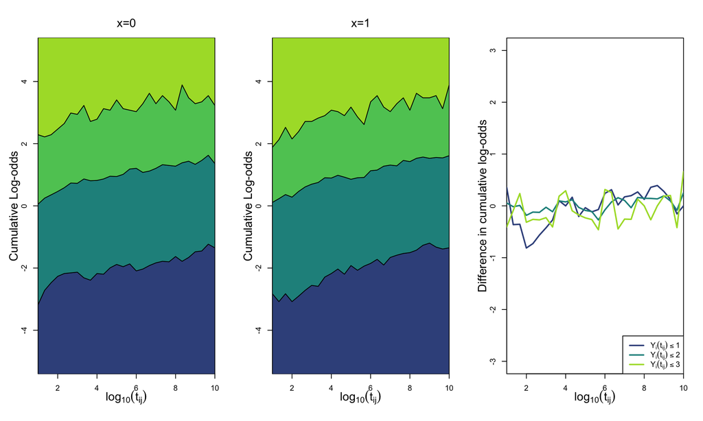

Have a look at the model object itself. We will do that here, but not for other models. For the model-based variance-covariance, notice that cross-sectional model parameter estimates are independent of the dependence model estimates, which is why this OMTM1 is robust to dependence model misspecification. Under dependence model misspecification estimates of cross-sectional model parameters are consistent, but standard errors are wrong and we need to use robust standard errors.

```r
names(mod.0)
```

```
## [1] "loglik"   "alpha"    "beta"     "gamma"    "vcov"     "rob.vcov" "no.info"
## [8] "control"
```

Maximum Log-likelihood

```r
mod.0$loglik
```

```
## [1] -18818.41
```

$\hat{\alpha}$

```r
mod.0$alpha
```

```
## [1] -2.90077225  0.08420654  2.10119006
```

$\hat{\beta}$

```r
mod.0$beta
```

```
## [1] -0.1605731  1.3835782  0.2303365
```

$\hat{\Gamma}$

```r
mod.0$gamma
```

```
## $`1`
##           [,1]     [,2]      [,3]
## [1,] 3.9514162 2.072623 0.8188568
## [2,] 1.9985391 4.046308 1.9257351
## [3,] 0.8107456 1.972030 3.8097209
```

Model-based covariance matrix

```r
round(mod.0$vcov,3)
```

```
##         [,1]   [,2]   [,3]   [,4]   [,5]   [,6]  [,7]  [,8]  [,9] [,10] [,11]
##  [1,]  0.006  0.005  0.005 -0.005 -0.007  0.006 0.000 0.000 0.000 0.000 0.000
##  [2,]  0.005  0.005  0.005 -0.005 -0.006  0.006 0.000 0.000 0.000 0.000 0.000
##  [3,]  0.005  0.005  0.006 -0.005 -0.006  0.006 0.000 0.000 0.000 0.000 0.000
##  [4,] -0.005 -0.005 -0.005  0.010  0.006 -0.013 0.000 0.000 0.000 0.000 0.000
##  [5,] -0.007 -0.006 -0.006  0.006  0.010 -0.010 0.000 0.000 0.000 0.000 0.000
##  [6,]  0.006  0.006  0.006 -0.013 -0.010  0.020 0.000 0.000 0.000 0.000 0.000
##  [7,]  0.000  0.000  0.000  0.000  0.000  0.000 0.017 0.008 0.008 0.010 0.002
##  [8,]  0.000  0.000  0.000  0.000  0.000  0.000 0.008 0.013 0.008 0.002 0.005
##  [9,]  0.000  0.000  0.000  0.000  0.000  0.000 0.008 0.008 0.019 0.002 0.002
## [10,]  0.000  0.000  0.000  0.000  0.000  0.000 0.010 0.002 0.002 0.014 0.004
## [11,]  0.000  0.000  0.000  0.000  0.000  0.000 0.002 0.005 0.002 0.004 0.008
## [12,]  0.000  0.000  0.000  0.000  0.000  0.000 0.002 0.002 0.006 0.004 0.004
## [13,]  0.000  0.000  0.000  0.000  0.000  0.000 0.010 0.002 0.002 0.010 0.002
## [14,]  0.000  0.000  0.000  0.000  0.000  0.000 0.002 0.005 0.002 0.002 0.005
```

[output cut: 17 more lines]

Robust, sandwich-based covariance matrix

```r
round(mod.0$rob.vcov,3)
```

```
##         [,1]   [,2]   [,3]   [,4]   [,5]   [,6]  [,7]  [,8]  [,9]  [,10]  [,11]
##  [1,]  0.006  0.004  0.004 -0.005 -0.006  0.006 0.000 0.000 0.000  0.000  0.000
##  [2,]  0.004  0.005  0.004 -0.005 -0.006  0.006 0.000 0.000 0.000  0.000  0.000
##  [3,]  0.004  0.004  0.006 -0.004 -0.006  0.006 0.000 0.000 0.000  0.000  0.000
##  [4,] -0.005 -0.005 -0.004  0.010  0.006 -0.013 0.000 0.001 0.000  0.000  0.001
##  [5,] -0.006 -0.006 -0.006  0.006  0.010 -0.010 0.000 0.000 0.000  0.000  0.000
##  [6,]  0.006  0.006  0.006 -0.013 -0.010  0.021 0.000 0.000 0.001 -0.001 -0.001
##  [7,]  0.000  0.000  0.000  0.000  0.000  0.000 0.018 0.010 0.009  0.011  0.003
##  [8,]  0.000  0.000  0.000  0.001  0.000  0.000 0.010 0.013 0.008  0.004  0.006
##  [9,]  0.000  0.000  0.000  0.000  0.000  0.001 0.009 0.008 0.019  0.003  0.002
## [10,]  0.000  0.000  0.000  0.000  0.000 -0.001 0.011 0.004 0.003  0.014  0.005
## [11,]  0.000  0.000  0.000  0.001  0.000 -0.001 0.003 0.006 0.002  0.005  0.008
## [12,]  0.000  0.000  0.000  0.000  0.000  0.001 0.002 0.002 0.006  0.004  0.004
## [13,]  0.001  0.000  0.000 -0.001 -0.001  0.001 0.011 0.003 0.003  0.010  0.002
## [14,]  0.000  0.000  0.000  0.000 -0.001  0.000 0.003 0.005 0.001  0.002  0.005
```

[output cut: 17 more lines]

Cross-sectional model parameter estimates

```r
# summary of the model
mod.0.sum  <- summary.omtm(mod.0, robust = FALSE)
kable(mod.0.sum$cs.table, digits = 4) %>%
  kable_styling(bootstrap_options = c("striped"))
```

|  | Estimate | StdErr | Z | p.value |
| --- | --- | --- | --- | --- |
| Intercept:Y<=1 | -2.9008 | 0.0789 | -36.7646 | 0.0000 |
| Intercept:Y<=2 | 0.0842 | 0.0715 | 1.1772 | 0.2391 |
| Intercept:Y<=3 | 2.1012 | 0.0766 | 27.4279 | 0.0000 |
| b_1 | -0.1606 | 0.1007 | -1.5946 | 0.1108 |
| b_2 | 1.3836 | 0.0994 | 13.9229 | 0.0000 |
| b_3 | 0.2303 | 0.1411 | 1.6324 | 0.1026 |

Dependence model parameter estimates

```r
kable(mod.0.sum$dependence.table, digits = 4) %>%
  kable_styling(bootstrap_options = c("striped"))
```

|  | Estimate | StdErr | Z | p.value |
| --- | --- | --- | --- | --- |
| gamma:11 | 3.9514 | 0.1289 | 30.6664 | 0 |
| gamma:12 | 2.0726 | 0.1122 | 18.4792 | 0 |
| gamma:13 | 0.8189 | 0.1364 | 6.0048 | 0 |
| gamma:21 | 1.9985 | 0.1169 | 17.1032 | 0 |
| gamma:22 | 4.0463 | 0.0867 | 46.6527 | 0 |
| gamma:23 | 1.9257 | 0.0963 | 19.9881 | 0 |
| gamma:31 | 0.8107 | 0.1480 | 5.4789 | 0 |
| gamma:32 | 1.9720 | 0.1007 | 19.5830 | 0 |
| gamma:33 | 3.8097 | 0.1013 | 37.5919 | 0 |

## 1.1 Dependence model reference state changed from 4 to 3

Now, when fitting the data, we change the reference state for the lagged response in the dependence model from 4 to 3. This model is equivalent to the one above, but the estimates of $\boldsymbol{\Gamma}$ will be different since the reference state has changed.

Cross-sectional model parameter estimates.

```r
# summary of the model
mod.0a.sum  <- summary.omtm(mod.0a, robust = FALSE)
kable(mod.0a.sum$cs.table, digits = 4) %>%
  kable_styling(bootstrap_options = c("striped"))
```

|  | Estimate | StdErr | Z | p.value |
| --- | --- | --- | --- | --- |
| Intercept:Y<=1 | -2.9008 | 0.0789 | -36.7647 | 0.0000 |
| Intercept:Y<=2 | 0.0842 | 0.0715 | 1.1771 | 0.2391 |
| Intercept:Y<=3 | 2.1012 | 0.0766 | 27.4278 | 0.0000 |
| b_1 | -0.1606 | 0.1007 | -1.5945 | 0.1108 |
| b_2 | 1.3836 | 0.0994 | 13.9229 | 0.0000 |
| b_3 | 0.2303 | 0.1411 | 1.6324 | 0.1026 |

Dependence model parameter estimates

```r
kable(mod.0a.sum$dependence.table, digits = 4) %>%
  kable_styling(bootstrap_options = c("striped"))
```

|  | Estimate | StdErr | Z | p.value |
| --- | --- | --- | --- | --- |
| gamma:11 | 6.1315 | 0.1217 | 50.3752 | 0 |
| gamma:12 | 3.0915 | 0.0931 | 33.2088 | 0 |
| gamma:14 | 2.9909 | 0.1310 | 22.8227 | 0 |
| gamma:21 | 3.0718 | 0.1018 | 30.1863 | 0 |
| gamma:22 | 3.9583 | 0.0463 | 85.4634 | 0 |
| gamma:24 | 1.8840 | 0.0888 | 21.2222 | 0 |
| gamma:41 | 2.9990 | 0.1419 | 21.1370 | 0 |
| gamma:42 | 1.8377 | 0.0917 | 20.0351 | 0 |
| gamma:44 | 3.8097 | 0.1013 | 37.5919 | 0 |

# 2 Marginalized PPO model: non-PO on the follow-up day association

Let's generate data from the following PO model
$$\begin{aligned}
logit\{\pi_{i,k}(t_{ij})\} &= \alpha_{k,0} + log_{10}(t_{ij}) [\beta_t+\beta_{t,2}I(Y_i(t_{ij})\leq 2) + \beta_{t,3}I(Y_i(t_{ij})\leq 3)] + \underbrace{[\beta_x + log_{10}(t_{ij}) \beta_{xt}]}_{\beta_{x}(t_{ij})} x_i \\
log \left( \frac{\mu_{i,k}^c(t_{ij})}{\mu_{i,K}^c(t_{ij})} \right) &= \Delta_{i,k}[\boldsymbol{X}_i(t_{ij})] + \sum_{l=1}^{K-1} \gamma^{kl} Y_{i,l}(t_{ij-1})
\end{aligned}$$

```r
Calc.TransProbs(Y.1, id=id, digs=4)
```

```
## $Tx.Mtx.Col2Row
##    Ylag
## Y        1      2      3      4
##   1 0.6762 0.0537 0.0276 0.0864
##   2 0.1784 0.8169 0.1523 0.1682
##   3 0.0455 0.0748 0.7409 0.1039
##   4 0.0999 0.0546 0.0792 0.6414
##
## $Joint.Mtx
##    Ylag
## Y        1      2      3      4
##   1 0.0858 0.0248 0.0070 0.0137
##   2 0.0226 0.3777 0.0384 0.0267
##   3 0.0058 0.0346 0.1869 0.0165
##   4 0.0127 0.0253 0.0200 0.1017
##
## $Marg.Prob
## Y
##      1      2      3      4
## 0.1313 0.4654 0.2437 0.1596
```

Simulated cumulative log odds over time and treatment effect over time.

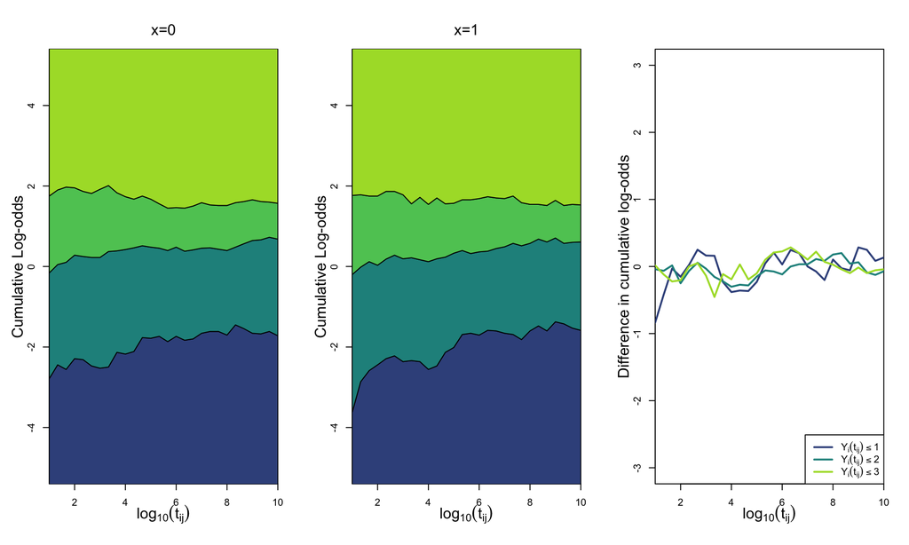

```r
par(mfrow=c(1,3))
dat = data.frame(id=id, Y.1=Y.1, t=t, tx=tx)
plot.states.lo(dat, "tx==0", "Y.1", "t", "x=0")
plot.states.lo(dat, "tx==1", "Y.1", "t", "x=1")
dat = data.frame(id=id, Y.1=Y.1, t=t, tx=tx)
plot.state.lo.diff(data=dat, Yvar="Y.1", timevar="t", the.title="")
```

Cross-sectional model parameter estimates.

```r
# summary of the model
mod.1.sum  <- summary.omtm(mod.1, robust = FALSE)
kable(mod.1.sum$cs.table, digits = 4) %>%
  kable_styling(bootstrap_options = c("striped"))
```

|  | Estimate | StdErr | Z | p.value |
| --- | --- | --- | --- | --- |
| Intercept:Y<=1 | -2.9062 | 0.1099 | -26.4453 | 0.0000 |
| Intercept:Y<=2 | -0.0745 | 0.0745 | -0.9999 | 0.3174 |
| Intercept:Y<=3 | 1.9357 | 0.0887 | 21.8119 | 0.0000 |
| b_1 | -0.1322 | 0.0976 | -1.3548 | 0.1755 |
| b_2 | 1.3938 | 0.1436 | 9.7057 | 0.0000 |
| b_3 | 0.1538 | 0.1342 | 1.1466 | 0.2515 |
| b_4 | -0.7029 | 0.1296 | -5.4254 | 0.0000 |
| b_5 | -1.7763 | 0.1569 | -11.3181 | 0.0000 |

Dependence model parameter estimates

```r
kable(mod.1.sum$dependence.table, digits = 4) %>%
  kable_styling(bootstrap_options = c("striped"))
```

|  | Estimate | StdErr | Z | p.value |
| --- | --- | --- | --- | --- |
| gamma:11 | 3.9001 | 0.0803 | 48.5913 | 0 |
| gamma:12 | 1.9898 | 0.0777 | 25.6181 | 0 |
| gamma:13 | 0.9678 | 0.1014 | 9.5436 | 0 |
| gamma:21 | 1.9291 | 0.0796 | 24.2309 | 0 |
| gamma:22 | 4.0416 | 0.0576 | 70.1502 | 0 |
| gamma:23 | 1.9795 | 0.0678 | 29.2131 | 0 |
| gamma:31 | 1.0651 | 0.1095 | 9.7244 | 0 |
| gamma:32 | 2.1286 | 0.0718 | 29.6319 | 0 |
| gamma:33 | 4.0230 | 0.0684 | 58.7959 | 0 |

# 3 Marginalized PO model: Dependence model is modified by the $x_i$

Let's generate data from the following PO model

$$\begin{aligned}
logit\{\pi_{i,k}(t_{ij})\} &= \alpha_{k,0} + log_{10}(t_{ij}) \beta_t + \underbrace{[\beta_x + log_{10}(t_{ij})\beta_{xt}]}_{\beta_x(t_{ij})}x_i \\
log \left( \frac{\mu_{i,k}^c(t_{ij})}{\mu_{i,K}^c(t_{ij})} \right) &= \Delta_{i,k}[\boldsymbol{X}_i(t_{ij})] + \sum_{l=1}^{K-1} [\gamma^{kl}+\gamma^{kl'}x_i] \cdot Y_{i,l}(t_{ij-1})
\end{aligned}$$

where $k \in \{1, 2, 3, 4\}$ and $N=1000$. The treatment indicator $x_i \sim bernoulli(0.5)$, $t_{ij}=j \in \{1, \dots, m_i\}$, $m_i=m=28$, $\boldsymbol{\alpha}=(-3,0,2)$, $\boldsymbol{\beta} = (\beta_x, \beta_t, \beta_{xt})= (-0.1, 1.5, 0.2)$, $\boldsymbol{\Gamma}=$ $\left(\begin{smallmatrix} 4 & 2 & 1 \\ 2 & 4 & 2 \\ 1 & 2 & 4 \end{smallmatrix}\right)$ and $\boldsymbol{\Gamma'}=$ $\left(\begin{smallmatrix} -1 & 0 & 0 \\ 0 & -1 & 0 \\ 0 & 0 & -1 \end{smallmatrix}\right)$

Simulated transition probabilities, joint probabilities, and marginal probabilities across all timepoints

For $x=0$

```r
Calc.TransProbs(Y.2[tx==0], id=id, digs=4)
```

```
## $Tx.Mtx.Col2Row
##    Ylag
## Y        1      2      3      4
##   1 0.6879 0.0511 0.0285 0.1194
##   2 0.2267 0.8685 0.1907 0.3104
##   3 0.0397 0.0592 0.7431 0.1701
##   4 0.0457 0.0212 0.0377 0.4000
##
## $Joint.Mtx
##    Ylag
## Y        1      2      3      4
##   1 0.0424 0.0154 0.0032 0.0030
##   2 0.0140 0.2620 0.0213 0.0077
##   3 0.0024 0.0179 0.0831 0.0042
##   4 0.0028 0.0064 0.0042 0.0099
##
## $Marg.Prob
## Y
##      1      2      3      4
## 0.0639 0.3050 0.1077 0.0234
```

For $x=1$

```r
Calc.TransProbs(Y.2[tx==1], id=id, digs=4)
```

```
## $Tx.Mtx.Col2Row
##    Ylag
## Y        1      2      3      4
##   1 0.4315 0.0991 0.0483 0.1455
##   2 0.4450 0.7532 0.3946 0.3409
##   3 0.0837 0.1208 0.5130 0.1926
##   4 0.0398 0.0269 0.0441 0.3210
##
## $Joint.Mtx
##    Ylag
## Y        1      2      3      4
##   1 0.0273 0.0301 0.0051 0.0038
##   2 0.0281 0.2291 0.0421 0.0089
##   3 0.0053 0.0367 0.0547 0.0050
##   4 0.0025 0.0082 0.0047 0.0083
##
## $Marg.Prob
## Y
##      1      2      3      4
## 0.0664 0.3081 0.1017 0.0237
```

Simulated cumulative log odds over time.

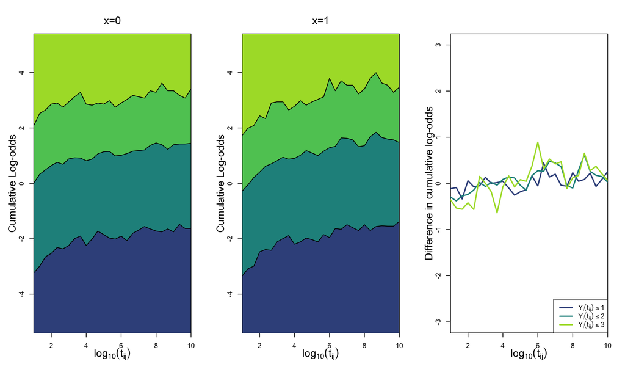

```r
par(mfrow=c(1,3))
dat = data.frame(id=id, Y.2=Y.2, t=t, tx=tx)
plot.states.lo(dat, "tx==0", "Y.2", "t", "x=0")
plot.states.lo(dat, "tx==1", "Y.2", "t", "x=1")
dat = data.frame(id=id, Y.2=Y.2, t=t, tx=tx)
plot.state.lo.diff(data=dat, Yvar="Y.2", timevar="t", the.title="")
```

Cross-sectional model parameter estimates

```r
# summary of the model
mod.2.sum  <- summary.omtm(mod.2, robust = FALSE)
kable(mod.2.sum$cs.table, digits = 4) %>%
  kable_styling(bootstrap_options = c("striped"))
```

|  | Estimate | StdErr | Z | p.value |
| --- | --- | --- | --- | --- |
| Intercept:Y<=1 | -2.9211 | 0.0769 | -37.9749 | 0.0000 |
| Intercept:Y<=2 | 0.1360 | 0.0719 | 1.8903 | 0.0587 |
| Intercept:Y<=3 | 2.1149 | 0.0763 | 27.7099 | 0.0000 |
| b_1 | -0.3103 | 0.0924 | -3.3593 | 0.0008 |
| b_2 | 1.3315 | 0.0999 | 13.3351 | 0.0000 |
| b_3 | 0.5302 | 0.1293 | 4.1015 | 0.0000 |

Dependence model parameter estimates

```r
kable(mod.2.sum$dependence.table, digits = 4) %>%
  kable_styling(bootstrap_options = c("striped"))
```

|  | Estimate | StdErr | Z | p.value |
| --- | --- | --- | --- | --- |
| gamma:11 | 3.8266 | 0.1753 | 21.8282 | 0.0000 |
| gamma:12 | 2.0365 | 0.1571 | 12.9673 | 0.0000 |
| gamma:13 | 0.9339 | 0.1917 | 4.8721 | 0.0000 |
| gamma:21 | 1.8172 | 0.1573 | 11.5508 | 0.0000 |
| gamma:22 | 3.9508 | 0.1209 | 32.6804 | 0.0000 |
| gamma:23 | 1.8845 | 0.1380 | 13.6570 | 0.0000 |
| gamma:31 | 0.7099 | 0.2032 | 3.4933 | 0.0005 |
| gamma:32 | 1.8827 | 0.1433 | 13.1366 | 0.0000 |
| gamma:33 | 3.8441 | 0.1473 | 26.0915 | 0.0000 |
| gamma:11' | -1.0694 | 0.2504 | -4.2712 | 0.0000 |
| gamma:12' | -0.2556 | 0.2139 | -1.1947 | 0.2322 |
| gamma:13' | -0.1681 | 0.2585 | -0.6503 | 0.5155 |
| gamma:21' | 0.2565 | 0.2250 | 1.1401 | 0.2543 |
| gamma:22' | -0.8867 | 0.1691 | -5.2447 | 0.0000 |
| gamma:23' | 0.1710 | 0.1917 | 0.8920 | 0.3724 |
| gamma:31' | 0.4441 | 0.2760 | 1.6090 | 0.1076 |
| gamma:32' | 0.0571 | 0.1965 | 0.2908 | 0.7712 |
| gamma:33' | -0.9049 | 0.2054 | -4.4043 | 0.0000 |

# 4 Marginalized PPO model: non-PO on the study day association and with dependence model modified by $x$.

Let's generate data from the following PO model
$$\begin{aligned}
logit\{\pi_{i,k}(t_{ij})\} &= \alpha_{k,0} + log_{10}(t_{ij}) [\beta_t+\beta_{t,2}I(Y_i(t_{ij})\leq 2) + \beta_{t,3}I(Y_i(t_{ij})\leq 3)] + \underbrace{[\beta_x + log_{10}(t_{ij}) \beta_{xt}]}_{\beta_{x}(t_{ij})} x_i \\
log \left( \frac{\mu_{i,k}^c(t_{ij})}{\mu_{i,K}^c(t_{ij})} \right) &= \Delta_{i,k}[\boldsymbol{X}_i(t_{ij})] + \sum_{l=1}^{K-1} [\gamma^{kl}+\gamma^{kl'}x_i] \cdot Y_{i,l}(t_{ij-1})
\end{aligned}$$

where $k \in \{1, 2, 3, 4\}$ and $N=1000$. The treatment indicators $x_i \sim bernoulli(0.5)$, $t_{ij}=j \in \{1, \dots, m_i\}$, $m_i = m = 28$, $\boldsymbol{\alpha}=(-3,0,2)$, $\boldsymbol{\beta}=(\beta_x, \beta_t, \beta_{xt})= (-0.1, 1.5, 0.2)$, $(\beta_{t,2}, \beta_{t,3})= (-1, -2)$ and $\boldsymbol{\Gamma}=$ $\left(\begin{smallmatrix} 4 & 2 & 1 \\ 2 & 4 & 2 \\ 1 & 2 & 4 \end{smallmatrix}\right)$ and $\boldsymbol{\Gamma'}=$ $\left(\begin{smallmatrix} -1 & 0 & 0 \\ 0 & -1 & 0 \\ 0 & 0 & -1 \end{smallmatrix}\right)$

```r
Calc.TransProbs(Y.3, id=id, digs=4)
```

```
## $Tx.Mtx.Col2Row
##    Ylag
## Y        1      2      3      4
##   1 0.5586 0.0823 0.0310 0.0895
##   2 0.2736 0.7328 0.2167 0.1939
##   3 0.0647 0.1159 0.6641 0.1325
##   4 0.1031 0.0690 0.0882 0.5842
##
## $Joint.Mtx
##    Ylag
## Y        1      2      3      4
##   1 0.0694 0.0375 0.0081 0.0140
##   2 0.0340 0.3342 0.0570 0.0304
##   3 0.0080 0.0529 0.1746 0.0208
##   4 0.0128 0.0315 0.0232 0.0916
##
## $Marg.Prob
## Y
##      1      2      3      4
## 0.1291 0.4556 0.2562 0.1591
```

Simulated cumulative log odds over time.

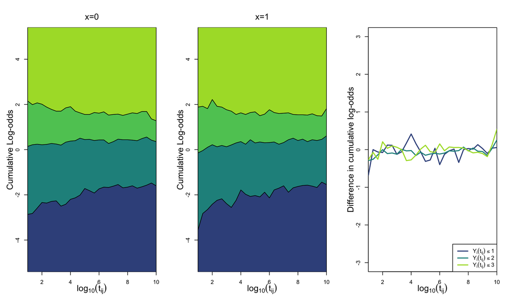

```r
par(mfrow=c(1,3))
dat = data.frame(id=id, Y.3=Y.3, t=t, tx=tx)
plot.states.lo(dat, "tx==0", "Y.3", "t", "x=0")
plot.states.lo(dat, "tx==1", "Y.3", "t", "x=1")
dat = data.frame(id=id, Y.3=Y.3, t=t, tx=tx)
plot.state.lo.diff(data=dat, Yvar="Y.3", timevar="t", the.title="")
```

Cross-sectional model parameter estimates

```r
# summary of the model
mod.3.sum  <- summary.omtm(mod.3, robust = FALSE)
kable(mod.3.sum$cs.table, digits = 4) %>%
  kable_styling(bootstrap_options = c("striped"))
```

|  | Estimate | StdErr | Z | p.value |
| --- | --- | --- | --- | --- |
| Intercept:Y<=1 | -2.8692 | 0.1020 | -28.1186 | 0.0000 |
| Intercept:Y<=2 | 0.1357 | 0.0733 | 1.8506 | 0.0642 |
| Intercept:Y<=3 | 2.1451 | 0.0868 | 24.7193 | 0.0000 |
| b_1 | -0.2097 | 0.0920 | -2.2802 | 0.0226 |
| b_2 | 1.3287 | 0.1346 | 9.8739 | 0.0000 |
| b_3 | 0.2573 | 0.1266 | 2.0324 | 0.0421 |
| b_4 | -1.0211 | 0.1117 | -9.1436 | 0.0000 |
| b_5 | -1.9871 | 0.1413 | -14.0631 | 0.0000 |

Dependence model parameter estimates

```r
kable(mod.3.sum$dependence.table, digits = 4) %>%
  kable_styling(bootstrap_options = c("striped"))
```

|  | Estimate | StdErr | Z | p.value |
| --- | --- | --- | --- | --- |
| gamma:11 | 4.0332 | 0.1174 | 34.3597 | 0.0000 |
| gamma:12 | 1.8896 | 0.1092 | 17.2988 | 0.0000 |
| gamma:13 | 0.8913 | 0.1517 | 5.8761 | 0.0000 |
| gamma:21 | 2.0059 | 0.1155 | 17.3671 | 0.0000 |
| gamma:22 | 3.8550 | 0.0794 | 48.5755 | 0.0000 |
| gamma:23 | 2.0089 | 0.0976 | 20.5918 | 0.0000 |
| gamma:31 | 1.0914 | 0.1536 | 7.1070 | 0.0000 |
| gamma:32 | 1.7994 | 0.0985 | 18.2660 | 0.0000 |
| gamma:33 | 4.0115 | 0.0963 | 41.6505 | 0.0000 |
| gamma:11' | -1.0166 | 0.1620 | -6.2756 | 0.0000 |
| gamma:12' | 0.2415 | 0.1464 | 1.6500 | 0.0989 |
| gamma:13' | -0.1206 | 0.1966 | -0.6135 | 0.5395 |
| gamma:21' | 0.0723 | 0.1526 | 0.4740 | 0.6355 |
| gamma:22' | -0.7921 | 0.1086 | -7.2946 | 0.0000 |
| gamma:23' | -0.1177 | 0.1274 | -0.9240 | 0.3555 |
| gamma:31' | -0.1367 | 0.2008 | -0.6810 | 0.4959 |
| gamma:32' | 0.2416 | 0.1302 | 1.8553 | 0.0635 |
| gamma:33' | -1.0393 | 0.1283 | -8.1003 | 0.0000 |

# 5 Marginalized PPO model: non-PO on the study day association, and with $y=1$ being an absorbing state

Let's generate data from the following PO model
$$\begin{aligned}
logit\{\pi_{i,k}(t_{ij})\} &= \alpha_{k,0} + log_{10}(t_{ij}) [\beta_t+\beta_{t,2}I(Y_i(t_{ij})\leq 2) + \beta_{t,3}I(Y_i(t_{ij})\leq 3)] + \underbrace{[\beta_x + log_{10}(t_{ij}) \beta_{xt}]}_{\beta_{x}(t_{ij})} x_i \\
log \left( \frac{\mu_{i,k}^c(t_{ij})}{\mu_{i,K}^c(t_{ij})} \right) &= \Delta_{i,k}[\boldsymbol{X}_i(t_{ij})] + \sum_{l=1}^{K-1} \gamma^{kl} Y_{i,l}(t_{ij-1})
\end{aligned}$$

where $k \in \{1, 2, 3, 4\}$ and $N=1000$. The treatment indicators $x_i \sim bernoulli(0.5)$, $t_{ij}=j \in \{1, \dots, m_i\}$, $m_i = m = 28$, $\boldsymbol{\alpha}=(-3,0,2)$, $\boldsymbol{\beta}=(\beta_x, \beta_t, \beta_{xt})= (-0.1, 1.5, 0.2)$, $(\beta_{t,2}, \beta_{t,3})= (-1, -2)$ and $\boldsymbol{\Gamma}=$ $\left(\begin{smallmatrix} 25 & 2 & 1 \\ -25 & 4 & 2 \\ -25 & 2 & 4 \end{smallmatrix}\right)$.

Notice that there are no transitions from $Y_{i,l}(t_{ij-1})=1$ to $Y_{i,l}(t_{ij-1})>1$

```r
Calc.TransProbs(Y.4, id=id, digs=4)
```

```
## $Tx.Mtx.Col2Row
##    Ylag
## Y        1      2      3      4
##   1 1.0000 0.0078 0.0030 0.0112
##   2 0.0000 0.8506 0.1565 0.1780
##   3 0.0000 0.0793 0.7609 0.1205
##   4 0.0000 0.0623 0.0796 0.6903
##
## $Joint.Mtx
##    Ylag
## Y        1      2      3      4
##   1 0.1305 0.0036 0.0008 0.0017
##   2 0.0000 0.3887 0.0407 0.0271
##   3 0.0000 0.0362 0.1979 0.0184
##   4 0.0000 0.0285 0.0207 0.1053
##
## $Marg.Prob
## Y
##      1      2      3      4
## 0.1365 0.4566 0.2525 0.1544
```

Simulated cumulative log odds over time.

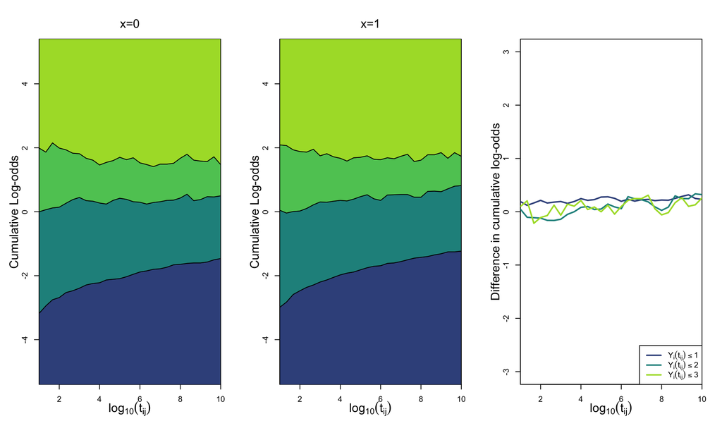

```r
par(mfrow=c(1,3))
dat = data.frame(id=id, Y.4=Y.4, t=t, tx=tx)
plot.states.lo(dat, "tx==0", "Y.4", "t", "x=0")
plot.states.lo(dat, "tx==1", "Y.4", "t", "x=1")
dat = data.frame(id=id, Y.4=Y.4, t=t, tx=tx)
plot.state.lo.diff(data=dat, Yvar="Y.4", timevar="t", the.title="")
```

Cross-sectional model parameter estimates

```r
# summary of the model
mod.4.sum  <- summary.omtm(mod.4, robust = FALSE)
kable(mod.4.sum$cs.table, digits = 4) %>%
  kable_styling(bootstrap_options = c("striped"))
```

|  | Estimate | StdErr | Z | p.value |
| --- | --- | --- | --- | --- |
| Intercept:Y<=1 | -3.0910 | 0.1527 | -20.2424 | 0.0000 |
| Intercept:Y<=2 | 0.0172 | 0.0759 | 0.2263 | 0.8209 |
| Intercept:Y<=3 | 2.0236 | 0.0926 | 21.8626 | 0.0000 |
| b_1 | -0.0382 | 0.1018 | -0.3755 | 0.7073 |
| b_2 | 1.6621 | 0.1465 | 11.3425 | 0.0000 |
| b_3 | 0.1866 | 0.1363 | 1.3694 | 0.1709 |
| b_4 | -1.1875 | 0.1400 | -8.4836 | 0.0000 |
| b_5 | -2.1764 | 0.1624 | -13.4034 | 0.0000 |

Dependence model parameter estimates

```r
kable(mod.4.sum$dependence.table, digits = 4) %>%
  kable_styling(bootstrap_options = c("striped"))
```

|  | Estimate | StdErr | Z | p.value |
| --- | --- | --- | --- | --- |
| gamma:11 | 25.0000 | 1.000e+08 | 0.0000 | 1.0000 |
| gamma:12 | 2.0215 | 1.841e-01 | 10.9812 | 0.0000 |
| gamma:13 | 0.7917 | 2.681e-01 | 2.9534 | 0.0031 |
| gamma:21 | -25.0000 | 1.000e+08 | 0.0000 | 1.0000 |
| gamma:22 | 3.9638 | 5.580e-02 | 71.0337 | 0.0000 |
| gamma:23 | 2.0206 | 6.660e-02 | 30.3483 | 0.0000 |
| gamma:31 | -25.0000 | 1.000e+08 | 0.0000 | 1.0000 |
| gamma:32 | 1.9761 | 6.860e-02 | 28.8255 | 0.0000 |
| gamma:33 | 3.9764 | 6.600e-02 | 60.2343 | 0.0000 |

# 6 Marginalized PPO model: with non-PO on the study day association, non-PO on treatment effect, and with State 1 being absorbing

Let's generate data from the following PO model
$$\begin{aligned}
logit\{\pi_{i,k}(t_{ij})\} &= \alpha_k + log_{10}(t_{ij}) [\beta_t+\beta_{t,2}I(Y_i(t_{ij})\leq 2) +\beta_{t,3}I(Y_i(t_{ij})\leq 3)] + \underbrace{ \{ \beta_x + log_{10}(t_{ij}) [\beta_{xt}+\beta_{xt,2}I(Y_i(t_{ij})\leq 2) +\beta_{xt,3}I(Y_i(t_{ij})\leq 3)]\} }_{\beta_x(t_{ij})} x_i\\
log \left( \frac{\mu_{i,k}^c(t_{ij})}{\mu_{i,K}^c(t_{ij})} \right) &= \Delta_{i,k}[\boldsymbol{X}_i(t_{ij})] + \sum_{l=1}^{K-1} \gamma^{kl} Y_{i,l}(t_{ij-1})
\end{aligned}$$

where $k \in \{1, 2, 3, 4\}$ and $N=1000$. The treatment indicators $x_i \sim bernoulli(0.5)$, $t_{ij}=j \in \{1, \dots, m_i\}$, $m_i = m = 28$, $\boldsymbol{\alpha}=(-3, 0, 2)$, $\boldsymbol{\beta}=(\beta_x, \beta_t, \beta_{xt})= (-0.1, 1.5, 0.2)$, $(\beta_{t,2}, \beta_{t,3}, \beta_{xt,2}, \beta_{xt,3}) = (-1, -2, 0.5, 1)$ and $\boldsymbol{\Gamma}=$ $\left(\begin{smallmatrix} 25 & 2 & 1 \\ -25 & 4 & 2 \\ -25 & 2 & 4 \end{smallmatrix}\right)$.

Notice that there are no transitions from $Y_{i,l}(t_{ij-1})=1$ to $Y_{i,l}(t_{ij-1})>1$

```r
Calc.TransProbs(Y.5, id=id, digs=4)
```

```
## $Tx.Mtx.Col2Row
##    Ylag
## Y        1      2      3      4
##   1 1.0000 0.0070 0.0033 0.0126
##   2 0.0000 0.8731 0.1641 0.1987
##   3 0.0000 0.0684 0.7663 0.1286
##   4 0.0000 0.0514 0.0662 0.6601
##
## $Joint.Mtx
##    Ylag
## Y        1      2      3      4
##   1 0.1299 0.0035 0.0008 0.0016
##   2 0.0000 0.4370 0.0404 0.0246
##   3 0.0000 0.0343 0.1885 0.0159
##   4 0.0000 0.0257 0.0163 0.0816
##
## $Marg.Prob
## Y
##      1      2      3      4
## 0.1358 0.5020 0.2387 0.1236
```

Simulated cumulative log odds over time.

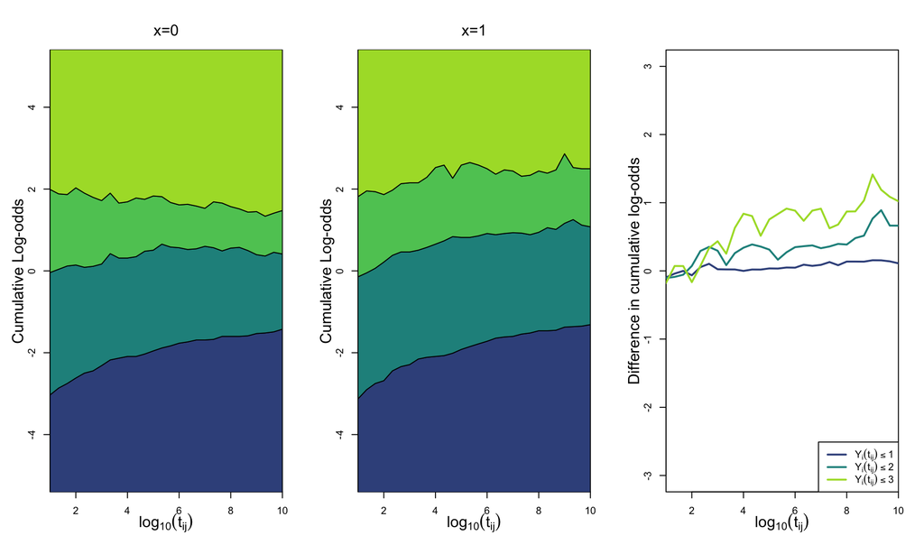

```r
par(mfrow=c(1,3))
dat = data.frame(id=id, Y.5=Y.5, t=t, tx=tx)
plot.states.lo(dat, "tx==0", "Y.5", "t", "x=0")
plot.states.lo(dat, "tx==1", "Y.5", "t", "x=1")
dat = data.frame(id=id, Y.5=Y.5, t=t, tx=tx)
plot.state.lo.diff(data=dat, Yvar="Y.5", timevar="t", the.title="")
```

Cross-sectional model parameter estimates

```r
# summary of the model
mod.5.sum  <- summary.omtm(mod.5, robust = FALSE)
kable(mod.5.sum$cs.table, digits = 4) %>%
  kable_styling(bootstrap_options = c("striped"))
```

|  | Estimate | StdErr | Z | p.value |
| --- | --- | --- | --- | --- |
| Intercept:Y<=1 | -3.0542 | 0.1547 | -19.7401 | 0.0000 |
| Intercept:Y<=2 | -0.0012 | 0.0779 | -0.0150 | 0.9880 |
| Intercept:Y<=3 | 1.9978 | 0.0936 | 21.3522 | 0.0000 |
| b_1 | -0.1529 | 0.1060 | -1.4430 | 0.1490 |
| b_2 | 1.6475 | 0.1544 | 10.6735 | 0.0000 |
| b_3 | 0.2366 | 0.1662 | 1.4233 | 0.1546 |
| b_4 | -1.0798 | 0.1558 | -6.9322 | 0.0000 |
| b_5 | -2.1267 | 0.1785 | -11.9165 | 0.0000 |
| b_6 | 0.4918 | 0.1337 | 3.6787 | 0.0002 |
| b_7 | 0.9710 | 0.1577 | 6.1577 | 0.0000 |

Dependence model parameter estimates

```r
kable(mod.5.sum$dependence.table, digits = 4) %>%
  kable_styling(bootstrap_options = c("striped"))
```

|  | Estimate | StdErr | Z | p.value |
| --- | --- | --- | --- | --- |
| gamma:11 | 25.0000 | 1.000e+08 | 0.0000 | 1.0000 |
| gamma:12 | 1.9157 | 1.914e-01 | 10.0079 | 0.0000 |
| gamma:13 | 0.8749 | 2.691e-01 | 3.2510 | 0.0011 |
| gamma:21 | -25.0000 | 1.000e+08 | 0.0000 | 1.0000 |
| gamma:22 | 3.9730 | 5.930e-02 | 66.9748 | 0.0000 |
| gamma:23 | 2.0568 | 7.220e-02 | 28.4796 | 0.0000 |
| gamma:31 | -25.0000 | 1.000e+08 | 0.0000 | 1.0000 |
| gamma:32 | 1.8800 | 7.320e-02 | 25.6836 | 0.0000 |
| gamma:33 | 4.0292 | 7.270e-02 | 55.3938 | 0.0000 |